# Developing an AI application

Going forward, AI algorithms will be incorporated into more and more everyday applications. For example, you might want to include an image classifier in a smart phone app. To do this, you'd use a deep learning model trained on hundreds of thousands of images as part of the overall application architecture. A large part of software development in the future will be using these types of models as common parts of applications.

In this project, you'll train an image classifier to recognize different species of flowers. You can imagine using something like this in a phone app that tells you the name of the flower your camera is looking at. In practice you'd train this classifier, then export it for use in your application. We'll be using [this dataset](http://www.robots.ox.ac.uk/~vgg/data/flowers/102/index.html) of 102 flower categories, you can see a few examples below.

[figure not shown]

The project is broken down into multiple steps:

- Load and preprocess the image dataset
- Train the image classifier on your dataset
- Use the trained classifier to predict image content

We'll lead you through each part which you'll implement in Python.

When you've completed this project, you'll have an application that can be trained on any set of labeled images. Here your network will be learning about flowers and end up as a command line application. But, what you do with your new skills depends on your imagination and effort in building a dataset. For example, imagine an app where you take a picture of a car, it tells you what the make and model is, then looks up information about it. Go build your own dataset and make something new.

First up is importing the packages you'll need. It's good practice to keep all the imports at the beginning of your code. As you work through this notebook and find you need to import a package, make sure to add the import up here.

```python
# Imports here
from __future__ import print_function, division

import os
import collections
import numpy as np
import json
import time
import copy
import torch

from torch import cuda
from torch import nn
from torch import optim
import torch.nn.functional as F
from torch.autograd import Variable
import torchvision
from torchvision import datasets, transforms, models
import torch.optim as optim
import matplotlib.pyplot as plt
from PIL import Image

from collections import OrderedDict

import helper
```

```python
is_cuda = torch.cuda.is_available()
```

## Load the data

Here you'll use `torchvision` to load the data ([documentation](http://pytorch.org/docs/0.3.0/torchvision/index.html)). The data should be included alongside this notebook, otherwise you can [download it here](https://s3.amazonaws.com/content.udacity-data.com/nd089/flower_data.tar.gz). The dataset is split into three parts, training, validation, and testing. For the training, you'll want to apply transformations such as random scaling, cropping, and flipping. This will help the network generalize leading to better performance. You'll also need to make sure the input data is resized to 224x224 pixels as required by the pre-trained networks.

The validation and testing sets are used to measure the model's performance on data it hasn't seen yet. For this you don't want any scaling or rotation transformations, but you'll need to resize then crop the images to the appropriate size.

The pre-trained networks you'll use were trained on the ImageNet dataset where each color channel was normalized separately. For all three sets you'll need to normalize the means and standard deviations of the images to what the network expects. For the means, it's `[0.485, 0.456, 0.406]` and for the standard deviations `[0.229, 0.224, 0.225]`, calculated from the ImageNet images. These values will shift each color channel to be centered at 0 and range from -1 to 1.

```python
data_dir = 'flowers'
train_dir = data_dir + '/train'
valid_dir = data_dir + '/valid'
test_dir = data_dir + '/test'
```

```python
# TODO: Define your transforms for the training, validation, and testing sets
train_transforms = transforms.Compose([transforms.RandomRotation(30),
                                       transforms.RandomResizedCrop(224),
                                       transforms.RandomHorizontalFlip(),
                                       transforms.ToTensor(),
                                       transforms.Normalize([0.485, 0.456, 0.406],
                                                            [0.229, 0.224, 0.225])])

test_transforms = transforms.Compose([transforms.Resize(256),
                                      transforms.CenterCrop(224),
                                      transforms.ToTensor(),
                                      transforms.Normalize([0.485, 0.456, 0.406],
                                                           [0.229, 0.224, 0.225])])

valid_transforms = transforms.Compose([transforms.Resize(256),
                                      transforms.CenterCrop(224),
                                      transforms.ToTensor(),
                                      transforms.Normalize([0.485, 0.456, 0.406],
                                                           [0.229, 0.224, 0.225])])
data_transforms = {"train_transforms": train_transforms,
                   "test_transforms": test_transforms,
                   "valid_transforms": valid_transforms}

# TODO: Load the datasets with ImageFolder
train_data = datasets.ImageFolder(train_dir, transform=data_transforms['train_transforms'])
test_data = datasets.ImageFolder(test_dir, transform=data_transforms['test_transforms'])
valid_data = datasets.ImageFolder(valid_dir, transform=data_transforms['valid_transforms'])

image_datasets = {"train_data": train_data,
                  "test_data": test_data,
                  "valid_data": valid_data}

# TODO: Using the image datasets and the trainforms, define the dataloaders
trainloader = torch.utils.data.DataLoader(image_datasets['train_data'], batch_size=64, shuffle=True)
testloader = torch.utils.data.DataLoader(image_datasets['test_data'], batch_size=32)
validloader = torch.utils.data.DataLoader(image_datasets['valid_data'], batch_size=32)

data_loaders = {"trainloader": trainloader,
                "testloader": testloader,
                "validloader": validloader}
```

### Label mapping

You'll also need to load in a mapping from category label to category name. You can find this in the file `cat_to_name.json`. It's a JSON object which you can read in with the [`json` module](https://docs.python.org/2/library/json.html). This will give you a dictionary mapping the integer encoded categories to the actual names of the flowers.

What this does is converts the cat_to_name.json file to a dictionary named *cat_to_name* where: *key* = a category represented by a string of digits (that's a string not an integer) *value* = category name that's a string of characters.

This means that `print(cat_to_name['21']` prints `fire lily` and `print(cat_to_name['46']` prints `wallflower`

If your classes are integers you will need to convert (cast) them to strings to get the dictionary to provide the appropriate flower name. You can check the type of the variable returned by using the *type()* function. So

```
myInt = 21
print(type(myInt), cat_to_name[str(myInt)])
```

would print <class 'int'> fire lily

```python
with open('cat_to_name.json', 'r') as f:
    cat_to_name = json.load(f)

cat_to_name = collections.OrderedDict(sorted(cat_to_name.items()))

print("cat_to_name type: {}".format(type(cat_to_name)))
for key,value in cat_to_name.items():
    print("key {} has value {}".format(key,value))
```

```
cat_to_name type: <class 'collections.OrderedDict'>
key 1 has value pink primrose
key 10 has value globe thistle
key 100 has value blanket flower
key 101 has value trumpet creeper
key 102 has value blackberry lily
key 11 has value snapdragon
key 12 has value colt's foot
key 13 has value king protea
key 14 has value spear thistle
key 15 has value yellow iris
key 16 has value globe-flower
key 17 has value purple coneflower
key 18 has value peruvian lily
key 19 has value balloon flower
key 2 has value hard-leaved pocket orchid
key 20 has value giant white arum lily
key 21 has value fire lily
key 22 has value pincushion flower
key 23 has value fritillary
key 24 has value red ginger
key 25 has value grape hyacinth
key 26 has value corn poppy
key 27 has value prince of wales feathers
key 28 has value stemless gentian
key 29 has value artichoke
key 3 has value canterbury bells
key 30 has value sweet william
key 31 has value carnation
key 32 has value garden phlox
key 33 has value love in the mist
key 34 has value mexican aster
key 35 has value alpine sea holly
key 36 has value ruby-lipped cattleya
key 37 has value cape flower
key 38 has value great masterwort
key 39 has value siam tulip
key 4 has value sweet pea
key 40 has value lenten rose
key 41 has value barbeton daisy
```

[output cut: 48 more lines]

```
key 86 has value tree mallow
key 87 has value magnolia
key 88 has value cyclamen
key 89 has value watercress
key 9 has value monkshood
key 90 has value canna lily
key 91 has value hippeastrum
key 92 has value bee balm
key 93 has value ball moss
key 94 has value foxglove
key 95 has value bougainvillea
key 96 has value camellia
key 97 has value mallow
key 98 has value mexican petunia
key 99 has value bromelia
```

# Building and training the classifier

Now that the data is ready, it's time to build and train the classifier. As usual, you should use one of the pretrained models from `torchvision.models` to get the image features. Build and train a new feed-forward classifier using those features.

We're going to leave this part up to you. If you want to talk through it with someone, chat with your fellow students! You can also ask questions on the forums or join the instructors in office hours.

Refer to [the rubric](https://review.udacity.com/#!/rubrics/1663/view) for guidance on successfully completing this section. Things you'll need to do:

- Load a [pre-trained network](http://pytorch.org/docs/master/torchvision/models.html) (If you need a starting point, the VGG networks work great and are straightforward to use)
- Define a new, untrained feed-forward network as a classifier, using ReLU activations and dropout
- Train the classifier layers using backpropagation using the pre-trained network to get the features
- Track the loss and accuracy on the validation set to determine the best hyperparameters

We've left a cell open for you below, but use as many as you need. Our advice is to break the problem up into smaller parts you can run separately. Check that each part is doing what you expect, then move on to the next. You'll likely find that as you work through each part, you'll need to go back and modify your previous code. This is totally normal!

When training make sure you're updating only the weights of the feed-forward network. You should be able to get the validation accuracy above 70% if you build everything right. Make sure to try different hyperparameters (learning rate, units in the classifier, epochs, etc) to find the best model. Save those hyperparameters to use as default values in the next part of the project.

```python
# TODO: Build and train your network
# load a pretrained network
model = models.densenet121(pretrained=True)
print(type(model))
model
```

```
<class 'torchvision.models.densenet.DenseNet'>
```

```
DenseNet(
  (features): Sequential(
    (conv0): Conv2d(3, 64, kernel_size=(7, 7), stride=(2, 2), padding=(3, 3), bias=False)
    (norm0): BatchNorm2d(64, eps=1e-05, momentum=0.1, affine=True, track_running_stats=True)
    (relu0): ReLU(inplace)
    (pool0): MaxPool2d(kernel_size=3, stride=2, padding=1, dilation=1, ceil_mode=False)
    (denseblock1): _DenseBlock(
      (denselayer1): _DenseLayer(
        (norm1): BatchNorm2d(64, eps=1e-05, momentum=0.1, affine=True, track_running_stats=True)
        (relu1): ReLU(inplace)
        (conv1): Conv2d(64, 128, kernel_size=(1, 1), stride=(1, 1), bias=False)
        (norm2): BatchNorm2d(128, eps=1e-05, momentum=0.1, affine=True, track_running_stats=True)
        (relu2): ReLU(inplace)
        (conv2): Conv2d(128, 32, kernel_size=(3, 3), stride=(1, 1), padding=(1, 1), bias=False)
      )
      (denselayer2): _DenseLayer(
        (norm1): BatchNorm2d(96, eps=1e-05, momentum=0.1, affine=True, track_running_stats=True)
        (relu1): ReLU(inplace)
        (conv1): Conv2d(96, 128, kernel_size=(1, 1), stride=(1, 1), bias=False)
        (norm2): BatchNorm2d(128, eps=1e-05, momentum=0.1, affine=True, track_running_stats=True)
        (relu2): ReLU(inplace)
        (conv2): Conv2d(128, 32, kernel_size=(3, 3), stride=(1, 1), padding=(1, 1), bias=False)
      )
      (denselayer3): _DenseLayer(
        (norm1): BatchNorm2d(128, eps=1e-05, momentum=0.1, affine=True, track_running_stats=True)
        (relu1): ReLU(inplace)
        (conv1): Conv2d(128, 128, kernel_size=(1, 1), stride=(1, 1), bias=False)
        (norm2): BatchNorm2d(128, eps=1e-05, momentum=0.1, affine=True, track_running_stats=True)
        (relu2): ReLU(inplace)
        (conv2): Conv2d(128, 32, kernel_size=(3, 3), stride=(1, 1), padding=(1, 1), bias=False)
      )
      (denselayer4): _DenseLayer(
        (norm1): BatchNorm2d(160, eps=1e-05, momentum=0.1, affine=True, track_running_stats=True)
        (relu1): ReLU(inplace)
        (conv1): Conv2d(160, 128, kernel_size=(1, 1), stride=(1, 1), bias=False)
        (norm2): BatchNorm2d(128, eps=1e-05, momentum=0.1, affine=True, track_running_stats=True)
        (relu2): ReLU(inplace)
        (conv2): Conv2d(128, 32, kernel_size=(3, 3), stride=(1, 1), padding=(1, 1), bias=False)
      )
      (denselayer5): _DenseLayer(
```

[output cut: 445 more lines]

```
        (conv2): Conv2d(128, 32, kernel_size=(3, 3), stride=(1, 1), padding=(1, 1), bias=False)
      )
      (denselayer16): _DenseLayer(
        (norm1): BatchNorm2d(992, eps=1e-05, momentum=0.1, affine=True, track_running_stats=True)
        (relu1): ReLU(inplace)
        (conv1): Conv2d(992, 128, kernel_size=(1, 1), stride=(1, 1), bias=False)
        (norm2): BatchNorm2d(128, eps=1e-05, momentum=0.1, affine=True, track_running_stats=True)
        (relu2): ReLU(inplace)
        (conv2): Conv2d(128, 32, kernel_size=(3, 3), stride=(1, 1), padding=(1, 1), bias=False)
      )
    )
    (norm5): BatchNorm2d(1024, eps=1e-05, momentum=0.1, affine=True, track_running_stats=True)
  )
  (classifier): Linear(in_features=1024, out_features=1000, bias=True)
)
```

```python
#freeze parameters
for param in model.parameters():
    param.requires_grad = False
```

```python
# Define a new, untrained feed-forward network as a classifier, using ReLU activations and dropout
# A sequential container. Modules will be added to it in the order they are passed in the constructor.
# Alternatively, an ordered dict of modules can also be passed in.
classifier = nn.Sequential(OrderedDict([
                          ('linear1', nn.Linear(1024, 512)),
                          ('relu1', nn.ReLU()),
                          ('dropout1', nn.Dropout(p=0.5)),
                          ('linear2', nn.Linear(512, 102)),
                          ('output', nn.LogSoftmax(dim=1))
                          ]))

model.classifier = classifier
```

```python
# Train the classifier layers using backpropagation using the pre-trained network to get the features
criterion = nn.NLLLoss()
optimizer = optim.Adam(model.classifier.parameters(), lr=0.001)

num_epochs = 20
steps = 0
running_loss = 0
print_every = 40

# need to move inputs, labels or else
# RuntimeError: Expected object of type torch.FloatTensor
# but found type torch.cuda.FloatTensor for argument #2 'weight'

if is_cuda:
        # Move model parameters to the GPU
        print("GPU")
        model.cuda()
else:
        print("CPU")
        model.cpu()
```

```
GPU
```

```python
# train model
for epoch in range(num_epochs):
    # model in training mode, dropout is on
    model.train()

    # for ii, (inputs, labels) in enumerate(trainloader):
    for inputs, labels in iter(data_loaders['trainloader']):
        steps += 1

        optimizer.zero_grad()

        inputs, labels = Variable(inputs), Variable(labels)
        # Move input and label tensors to the GPU
        if is_cuda:
            inputs, labels = inputs.cuda(), labels.cuda()


        output = model.forward(inputs)
        loss = criterion(output, labels)
        loss.backward()
        optimizer.step()
        running_loss += loss.data[0]

        if steps % print_every == 0:
            # model in inference mode, dropout is off
            model.eval()

            accuracy = 0
            test_loss = 0

            for ii, (inputs, labels) in enumerate(data_loaders['validloader']):
                # move input and label tensors to the GPU
                if is_cuda:
                    inputs = inputs.cuda()
                    labels = labels.cuda()

                inputs = Variable(inputs)
                labels = Variable(labels)

                output = model.forward(inputs)
                test_loss += criterion(output, labels).data[0]

                # calculate the accuracy
                # model's output is LogSoftmax, take exponential to get the probabilities
                probabilities = torch.exp(output).data
                # class with highest probability is our predicted class, compare with true label
                equality = (labels.data == probabilities.max(1)[1])
                # accuracy is the number of correct predictions divided by all the predictions, so just take the mean
                accuracy += equality.type_as(torch.FloatTensor()).mean()


            print("Epoch: {}/{}.. ".format(epoch+1, num_epochs),
              "Training Loss: {:.3f}.. ".format(running_loss/print_every),
              "Valid Loss: {:.3f}.. ".format(test_loss/len(data_loaders['validloader'])),
              "Valid Accuracy: {:.3f}".format(accuracy/len(data_loaders['validloader'])))

            running_loss = 0

            # make sure dropout is on for training
            model.train()
```

```
Epoch: 1/20..  Training Loss: 4.253..  Valid Loss: 3.579..  Valid Accuracy: 0.294
Epoch: 1/20..  Training Loss: 3.299..  Valid Loss: 2.350..  Valid Accuracy: 0.504
Epoch: 2/20..  Training Loss: 2.458..  Valid Loss: 1.635..  Valid Accuracy: 0.648
Epoch: 2/20..  Training Loss: 1.964..  Valid Loss: 1.174..  Valid Accuracy: 0.789
Epoch: 2/20..  Training Loss: 1.612..  Valid Loss: 0.895..  Valid Accuracy: 0.820
Epoch: 3/20..  Training Loss: 1.453..  Valid Loss: 0.765..  Valid Accuracy: 0.850
Epoch: 3/20..  Training Loss: 1.250..  Valid Loss: 0.653..  Valid Accuracy: 0.860
Epoch: 4/20..  Training Loss: 1.173..  Valid Loss: 0.564..  Valid Accuracy: 0.876
Epoch: 4/20..  Training Loss: 1.075..  Valid Loss: 0.517..  Valid Accuracy: 0.881
Epoch: 4/20..  Training Loss: 1.043..  Valid Loss: 0.450..  Valid Accuracy: 0.902
Epoch: 5/20..  Training Loss: 0.949..  Valid Loss: 0.440..  Valid Accuracy: 0.897
Epoch: 5/20..  Training Loss: 0.917..  Valid Loss: 0.401..  Valid Accuracy: 0.910
Epoch: 6/20..  Training Loss: 0.909..  Valid Loss: 0.387..  Valid Accuracy: 0.902
Epoch: 6/20..  Training Loss: 0.840..  Valid Loss: 0.366..  Valid Accuracy: 0.931
Epoch: 6/20..  Training Loss: 0.839..  Valid Loss: 0.387..  Valid Accuracy: 0.915
Epoch: 7/20..  Training Loss: 0.802..  Valid Loss: 0.341..  Valid Accuracy: 0.917
Epoch: 7/20..  Training Loss: 0.770..  Valid Loss: 0.313..  Valid Accuracy: 0.929
Epoch: 7/20..  Training Loss: 0.754..  Valid Loss: 0.307..  Valid Accuracy: 0.923
Epoch: 8/20..  Training Loss: 0.768..  Valid Loss: 0.305..  Valid Accuracy: 0.931
Epoch: 8/20..  Training Loss: 0.737..  Valid Loss: 0.291..  Valid Accuracy: 0.933
Epoch: 9/20..  Training Loss: 0.696..  Valid Loss: 0.288..  Valid Accuracy: 0.922
Epoch: 9/20..  Training Loss: 0.684..  Valid Loss: 0.277..  Valid Accuracy: 0.926
Epoch: 9/20..  Training Loss: 0.678..  Valid Loss: 0.271..  Valid Accuracy: 0.932
Epoch: 10/20..  Training Loss: 0.682..  Valid Loss: 0.279..  Valid Accuracy: 0.935
Epoch: 10/20..  Training Loss: 0.658..  Valid Loss: 0.272..  Valid Accuracy: 0.943
Epoch: 11/20..  Training Loss: 0.688..  Valid Loss: 0.279..  Valid Accuracy: 0.928
Epoch: 11/20..  Training Loss: 0.657..  Valid Loss: 0.261..  Valid Accuracy: 0.932
Epoch: 11/20..  Training Loss: 0.641..  Valid Loss: 0.251..  Valid Accuracy: 0.933
Epoch: 12/20..  Training Loss: 0.652..  Valid Loss: 0.241..  Valid Accuracy: 0.946
Epoch: 12/20..  Training Loss: 0.576..  Valid Loss: 0.219..  Valid Accuracy: 0.944
Epoch: 13/20..  Training Loss: 0.634..  Valid Loss: 0.241..  Valid Accuracy: 0.941
Epoch: 13/20..  Training Loss: 0.630..  Valid Loss: 0.238..  Valid Accuracy: 0.937
Epoch: 13/20..  Training Loss: 0.566..  Valid Loss: 0.235..  Valid Accuracy: 0.943
Epoch: 14/20..  Training Loss: 0.615..  Valid Loss: 0.230..  Valid Accuracy: 0.939
Epoch: 14/20..  Training Loss: 0.627..  Valid Loss: 0.251..  Valid Accuracy: 0.934
Epoch: 14/20..  Training Loss: 0.589..  Valid Loss: 0.226..  Valid Accuracy: 0.944
Epoch: 15/20..  Training Loss: 0.607..  Valid Loss: 0.224..  Valid Accuracy: 0.944
Epoch: 15/20..  Training Loss: 0.557..  Valid Loss: 0.222..  Valid Accuracy: 0.944
Epoch: 16/20..  Training Loss: 0.556..  Valid Loss: 0.235..  Valid Accuracy: 0.929
Epoch: 16/20..  Training Loss: 0.613..  Valid Loss: 0.223..  Valid Accuracy: 0.944
Epoch: 16/20..  Training Loss: 0.557..  Valid Loss: 0.219..  Valid Accuracy: 0.937
Epoch: 17/20..  Training Loss: 0.548..  Valid Loss: 0.225..  Valid Accuracy: 0.940
Epoch: 17/20..  Training Loss: 0.549..  Valid Loss: 0.209..  Valid Accuracy: 0.946
Epoch: 18/20..  Training Loss: 0.582..  Valid Loss: 0.237..  Valid Accuracy: 0.938
Epoch: 18/20..  Training Loss: 0.560..  Valid Loss: 0.201..  Valid Accuracy: 0.943
Epoch: 18/20..  Training Loss: 0.557..  Valid Loss: 0.223..  Valid Accuracy: 0.949
Epoch: 19/20..  Training Loss: 0.535..  Valid Loss: 0.207..  Valid Accuracy: 0.951
Epoch: 19/20..  Training Loss: 0.524..  Valid Loss: 0.202..  Valid Accuracy: 0.952
Epoch: 20/20..  Training Loss: 0.491..  Valid Loss: 0.218..  Valid Accuracy: 0.940
Epoch: 20/20..  Training Loss: 0.541..  Valid Loss: 0.215..  Valid Accuracy: 0.946
Epoch: 20/20..  Training Loss: 0.505..  Valid Loss: 0.214..  Valid Accuracy: 0.945
```

## Testing your network

It's good practice to test your trained network on test data, images the network has never seen either in training or validation. This will give you a good estimate for the model's performance on completely new images. Run the test images through the network and measure the accuracy, the same way you did validation. You should be able to reach around 70% accuracy on the test set if the model has been trained well.

```python
# validate model
# need to move inputs, labels or else
# RuntimeError: Expected object of type torch.FloatTensor
# but found type torch.cuda.FloatTensor for argument #2 'weight'

model.eval()
accuracy = 0
test_loss = 0
for ii, (inputs, labels) in enumerate(data_loaders['testloader']):
    # move input and label tensors to the GPU
    if is_cuda:
       inputs = inputs.cuda()
       labels = labels.cuda()

    inputs = Variable(inputs)
    labels = Variable(labels)

    output = model.forward(inputs)
    test_loss += criterion(output, labels).data[0]

    # calculate the accuracy
    # model’s output is LogSoftmax, take exponential to get the probabilities
    probabilities = torch.exp(output).data
    # class with highest probability is our predicted class, compare with true label
    equality = (labels.data == probabilities.max(1)[1])
    # accuracy is the number of correct predictions divided by all the predictions, so just take the mean
    accuracy += equality.type_as(torch.FloatTensor()).mean()

    print("Test Loss: {:.3f}.. ".format(test_loss/len(data_loaders['testloader'])),
          "Test Accuracy: {:.3f}".format(accuracy/len(data_loaders['testloader'])))
```

```
Test Loss: 0.010..  Test Accuracy: 0.037
Test Loss: 0.021..  Test Accuracy: 0.072
Test Loss: 0.025..  Test Accuracy: 0.111
Test Loss: 0.036..  Test Accuracy: 0.147
Test Loss: 0.051..  Test Accuracy: 0.179
Test Loss: 0.060..  Test Accuracy: 0.214
Test Loss: 0.090..  Test Accuracy: 0.244
Test Loss: 0.098..  Test Accuracy: 0.281
Test Loss: 0.101..  Test Accuracy: 0.319
Test Loss: 0.107..  Test Accuracy: 0.355
Test Loss: 0.121..  Test Accuracy: 0.387
Test Loss: 0.129..  Test Accuracy: 0.423
Test Loss: 0.130..  Test Accuracy: 0.462
Test Loss: 0.131..  Test Accuracy: 0.500
Test Loss: 0.142..  Test Accuracy: 0.532
Test Loss: 0.152..  Test Accuracy: 0.570
Test Loss: 0.154..  Test Accuracy: 0.608
Test Loss: 0.156..  Test Accuracy: 0.647
Test Loss: 0.156..  Test Accuracy: 0.685
Test Loss: 0.160..  Test Accuracy: 0.722
Test Loss: 0.167..  Test Accuracy: 0.758
Test Loss: 0.175..  Test Accuracy: 0.794
Test Loss: 0.186..  Test Accuracy: 0.829
Test Loss: 0.189..  Test Accuracy: 0.867
Test Loss: 0.194..  Test Accuracy: 0.903
Test Loss: 0.228..  Test Accuracy: 0.931
```

## Save the checkpoint

Now that your network is trained, save the model so you can load it later for making predictions. You probably want to save other things such as the mapping of classes to indices which you get from one of the image datasets: `image_datasets['train'].class_to_idx`. You can attach this to the model as an attribute which makes inference easier later on.

`model.class_to_idx = image_datasets['train'].class_to_idx`

Remember that you'll want to completely rebuild the model later so you can use it for inference. Make sure to include any information you need in the checkpoint. If you want to load the model and keep training, you'll want to save the number of epochs as well as the optimizer state, `optimizer.state_dict`. You'll likely want to use this trained model in the next part of the project, so best to save it now.

```python
print("Our model: \n\n", model, "\n")
print("The state dict keys: \n\n", model.state_dict().keys())

# TODO: Save the checkpoint
model.class_to_idx = train_data.class_to_idx
checkpoint = {
    'state_dict': model.state_dict(),
    'epochs': num_epochs + 1,
    'optimizer': optimizer.state_dict,
    'class_to_idx': image_datasets['train_data'].class_to_idx
}

torch.save(checkpoint, "checkpoint_notebook.pth.tar")
```

```
Our model:

 DenseNet(
  (features): Sequential(
    (conv0): Conv2d(3, 64, kernel_size=(7, 7), stride=(2, 2), padding=(3, 3), bias=False)
    (norm0): BatchNorm2d(64, eps=1e-05, momentum=0.1, affine=True, track_running_stats=True)
    (relu0): ReLU(inplace)
    (pool0): MaxPool2d(kernel_size=3, stride=2, padding=1, dilation=1, ceil_mode=False)
    (denseblock1): _DenseBlock(
      (denselayer1): _DenseLayer(
        (norm1): BatchNorm2d(64, eps=1e-05, momentum=0.1, affine=True, track_running_stats=True)
        (relu1): ReLU(inplace)
        (conv1): Conv2d(64, 128, kernel_size=(1, 1), stride=(1, 1), bias=False)
        (norm2): BatchNorm2d(128, eps=1e-05, momentum=0.1, affine=True, track_running_stats=True)
        (relu2): ReLU(inplace)
        (conv2): Conv2d(128, 32, kernel_size=(3, 3), stride=(1, 1), padding=(1, 1), bias=False)
      )
      (denselayer2): _DenseLayer(
        (norm1): BatchNorm2d(96, eps=1e-05, momentum=0.1, affine=True, track_running_stats=True)
        (relu1): ReLU(inplace)
        (conv1): Conv2d(96, 128, kernel_size=(1, 1), stride=(1, 1), bias=False)
        (norm2): BatchNorm2d(128, eps=1e-05, momentum=0.1, affine=True, track_running_stats=True)
        (relu2): ReLU(inplace)
        (conv2): Conv2d(128, 32, kernel_size=(3, 3), stride=(1, 1), padding=(1, 1), bias=False)
      )
      (denselayer3): _DenseLayer(
        (norm1): BatchNorm2d(128, eps=1e-05, momentum=0.1, affine=True, track_running_stats=True)
        (relu1): ReLU(inplace)
        (conv1): Conv2d(128, 128, kernel_size=(1, 1), stride=(1, 1), bias=False)
        (norm2): BatchNorm2d(128, eps=1e-05, momentum=0.1, affine=True, track_running_stats=True)
        (relu2): ReLU(inplace)
        (conv2): Conv2d(128, 32, kernel_size=(3, 3), stride=(1, 1), padding=(1, 1), bias=False)
      )
      (denselayer4): _DenseLayer(
        (norm1): BatchNorm2d(160, eps=1e-05, momentum=0.1, affine=True, track_running_stats=True)
        (relu1): ReLU(inplace)
        (conv1): Conv2d(160, 128, kernel_size=(1, 1), stride=(1, 1), bias=False)
        (norm2): BatchNorm2d(128, eps=1e-05, momentum=0.1, affine=True, track_running_stats=True)
        (relu2): ReLU(inplace)
        (conv2): Conv2d(128, 32, kernel_size=(3, 3), stride=(1, 1), padding=(1, 1), bias=False)
```

[output cut: 457 more lines]

```
    )
    (norm5): BatchNorm2d(1024, eps=1e-05, momentum=0.1, affine=True, track_running_stats=True)
  )
  (classifier): Sequential(
    (linear1): Linear(in_features=1024, out_features=512, bias=True)
    (relu1): ReLU()
    (dropout1): Dropout(p=0.5)
    (linear2): Linear(in_features=512, out_features=102, bias=True)
    (output): LogSoftmax()
  )
)

The state dict keys:

 odict_keys(['features.conv0.weight', 'features.norm0.weight', 'features.norm0.bias', 'features.norm0.running_mean', 'features.norm0.running_var', 'features.denseblock1.denselayer1.norm1.weight', 'features.denseblock1.denselayer1.norm1.bias', 'features.denseblock1.denselayer1.norm1.running_mean', 'f…
```

## Loading the checkpoint

At this point it's good to write a function that can load a checkpoint and rebuild the model. That way you can come back to this project and keep working on it without having to retrain the network.

```python
# TODO: Write a function that loads a checkpoint and rebuilds the model
# For this notebook, we do not need to load the model to keep training
# You need to get your model from Pytorch again and rebuild your classifier
# before loading your state_dict.
# Otherwise your model does not have a layer named fc1 which is what the Keyerror is trying to convey

def load_model_checkpoint(filepath):
    checkpoint = torch.load(filepath)
    model = models.densenet121(pretrained=True)

    classifier = nn.Sequential(OrderedDict([
                          ('linear1', nn.Linear(1024, 512)),
                          ('relu1', nn.ReLU()),
                          ('dropout1', nn.Dropout(p=0.5)),
                          ('linear2', nn.Linear(512, 102)),
                          ('output', nn.LogSoftmax(dim=1))
                          ]))

    model.classifier = classifier

    state_dict = checkpoint['state_dict']

    model.load_state_dict(state_dict)
    model.class_to_idx = checkpoint['class_to_idx']

    for param in model.parameters():
        param.requires_grad = False

    return model
```

```python
print("loading model checkpoint from file system")
model = load_model_checkpoint('checkpoint_notebook.pth.tar')
print("Our loaded model: \n\n", model, "\n")
print("The state dict keys: \n\n", model.state_dict().keys())
```

```
loading model checkpoint from file system
```

```
Our loaded model:

 DenseNet(
  (features): Sequential(
    (conv0): Conv2d(3, 64, kernel_size=(7, 7), stride=(2, 2), padding=(3, 3), bias=False)
    (norm0): BatchNorm2d(64, eps=1e-05, momentum=0.1, affine=True, track_running_stats=True)
    (relu0): ReLU(inplace)
    (pool0): MaxPool2d(kernel_size=3, stride=2, padding=1, dilation=1, ceil_mode=False)
    (denseblock1): _DenseBlock(
      (denselayer1): _DenseLayer(
        (norm1): BatchNorm2d(64, eps=1e-05, momentum=0.1, affine=True, track_running_stats=True)
        (relu1): ReLU(inplace)
        (conv1): Conv2d(64, 128, kernel_size=(1, 1), stride=(1, 1), bias=False)
        (norm2): BatchNorm2d(128, eps=1e-05, momentum=0.1, affine=True, track_running_stats=True)
        (relu2): ReLU(inplace)
        (conv2): Conv2d(128, 32, kernel_size=(3, 3), stride=(1, 1), padding=(1, 1), bias=False)
      )
      (denselayer2): _DenseLayer(
        (norm1): BatchNorm2d(96, eps=1e-05, momentum=0.1, affine=True, track_running_stats=True)
        (relu1): ReLU(inplace)
        (conv1): Conv2d(96, 128, kernel_size=(1, 1), stride=(1, 1), bias=False)
        (norm2): BatchNorm2d(128, eps=1e-05, momentum=0.1, affine=True, track_running_stats=True)
        (relu2): ReLU(inplace)
        (conv2): Conv2d(128, 32, kernel_size=(3, 3), stride=(1, 1), padding=(1, 1), bias=False)
      )
      (denselayer3): _DenseLayer(
        (norm1): BatchNorm2d(128, eps=1e-05, momentum=0.1, affine=True, track_running_stats=True)
        (relu1): ReLU(inplace)
        (conv1): Conv2d(128, 128, kernel_size=(1, 1), stride=(1, 1), bias=False)
        (norm2): BatchNorm2d(128, eps=1e-05, momentum=0.1, affine=True, track_running_stats=True)
        (relu2): ReLU(inplace)
        (conv2): Conv2d(128, 32, kernel_size=(3, 3), stride=(1, 1), padding=(1, 1), bias=False)
      )
      (denselayer4): _DenseLayer(
        (norm1): BatchNorm2d(160, eps=1e-05, momentum=0.1, affine=True, track_running_stats=True)
        (relu1): ReLU(inplace)
        (conv1): Conv2d(160, 128, kernel_size=(1, 1), stride=(1, 1), bias=False)
        (norm2): BatchNorm2d(128, eps=1e-05, momentum=0.1, affine=True, track_running_stats=True)
        (relu2): ReLU(inplace)
        (conv2): Conv2d(128, 32, kernel_size=(3, 3), stride=(1, 1), padding=(1, 1), bias=False)
```

[output cut: 457 more lines]

```
    )
    (norm5): BatchNorm2d(1024, eps=1e-05, momentum=0.1, affine=True, track_running_stats=True)
  )
  (classifier): Sequential(
    (linear1): Linear(in_features=1024, out_features=512, bias=True)
    (relu1): ReLU()
    (dropout1): Dropout(p=0.5)
    (linear2): Linear(in_features=512, out_features=102, bias=True)
    (output): LogSoftmax()
  )
)

The state dict keys:

 odict_keys(['features.conv0.weight', 'features.norm0.weight', 'features.norm0.bias', 'features.norm0.running_mean', 'features.norm0.running_var', 'features.denseblock1.denselayer1.norm1.weight', 'features.denseblock1.denselayer1.norm1.bias', 'features.denseblock1.denselayer1.norm1.running_mean', 'f…
```

# Inference for classification

Now you'll write a function to use a trained network for inference. That is, you'll pass an image into the network and predict the class of the flower in the image. Write a function called `predict` that takes an image and a model, then returns the top $K$ most likely classes along with the probabilities. It should look like

```
probs, classes = predict(image_path, model)
print(probs)
print(classes)
> [ 0.01558163  0.01541934  0.01452626  0.01443549  0.01407339]
> ['70', '3', '45', '62', '55']
```

First you'll need to handle processing the input image such that it can be used in your network.

## Image Preprocessing

You'll want to use `PIL` to load the image ([documentation](https://pillow.readthedocs.io/en/latest/reference/Image.html)). It's best to write a function that preprocesses the image so it can be used as input for the model. This function should process the images in the same manner used for training.

First, resize the images where the shortest side is 256 pixels, keeping the aspect ratio. This can be done with the [`thumbnail`](http://pillow.readthedocs.io/en/3.1.x/reference/Image.html#PIL.Image.Image.thumbnail) or [`resize`](http://pillow.readthedocs.io/en/3.1.x/reference/Image.html#PIL.Image.Image.thumbnail) methods. Then you'll need to crop out the center 224x224 portion of the image.

Color channels of images are typically encoded as integers 0-255, but the model expected floats 0-1. You'll need to convert the values. It's easiest with a Numpy array, which you can get from a PIL image like so `np_image = np.array(pil_image)`.

As before, the network expects the images to be normalized in a specific way. For the means, it's `[0.485, 0.456, 0.406]` and for the standard deviations `[0.229, 0.224, 0.225]`. You'll want to subtract the means from each color channel, then divide by the standard deviation.

And finally, PyTorch expects the color channel to be the first dimension but it's the third dimension in the PIL image and Numpy array. You can reorder dimensions using [`ndarray.transpose`](https://docs.scipy.org/doc/numpy-1.13.0/reference/generated/numpy.ndarray.transpose.html). The color channel needs to be first and retain the order of the other two dimensions.

```python
# the objective of process_image func is to convert an image file to a Tensor object
# which can be used later, like for prediction ...
def process_image(image_path):
    ''' Scales, crops, and normalizes a PIL image for a PyTorch model,
        returns an Numpy array
    '''

    # Process a PIL image for use in a PyTorch model
    raw_image = Image.open(image_path)

    # preserve aspect ratios with thumbnail_size max resolution
    thumbnail_size = 256,256
    raw_image.thumbnail(thumbnail_size, Image.ANTIALIAS)
    width, height = raw_image.size

    # crop  box – The crop rectangle, as a (left, upper, right, lower)-tuple.
    # 224 x 224
    crop_width = 224
    crop_height = 224
    left = (width - crop_width)/2
    upper = (height - crop_height)/2
    right = (width + crop_width)/2
    lower = (height + crop_height)/2
    raw_image_crop = raw_image.crop((left, upper, right, lower))


    # normalize the color channels
    # dtype = float64 is a double - do not use because torch then coverts the array to a DoubleTensor
    # and we want a FloatTensor
    # https://github.com/pytorch/pytorch/issues/541
    np_raw_image = np.array(raw_image_crop, dtype=np.dtype(np.float32))
    norm_mean = np.array([0.485, 0.456, 0.406])
    norm_std_dev = np.array([0.229, 0.224, 0.225])
    np_raw_image = ((np_raw_image/255) - norm_mean) / norm_std_dev

    transposed_image = np_raw_image.transpose(2, 0, 1)
    # transpose turns all the float32 values back to float64!
    # torch views float64 as a double and thus creates a DoubleTensor when
    # torch.from_numpy(transposed_image)
    tensor_image = torch.FloatTensor(transposed_image)
    return tensor_image
```

To check your work, the function below converts a PyTorch tensor and displays it in the notebook. If your `process_image` function works, running the output through this function should return the original image (except for the cropped out portions).

```python
def imshow(image, ax=None, title=None):
    """Imshow for Tensor."""
    if ax is None:
        fig, ax = plt.subplots()

    # PyTorch tensors assume the color channel is the first dimension
    # but matplotlib assumes is the third dimension
    image = image.numpy().transpose((1, 2, 0))

    # Undo preprocessing
    mean = np.array([0.485, 0.456, 0.406])
    std = np.array([0.229, 0.224, 0.225])
    image = std * image + mean

    # Image needs to be clipped between 0 and 1 or it looks like noise when displayed
    image = np.clip(image, 0, 1)

    ax.imshow(image)

    return ax
```

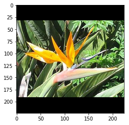

```python
image = process_image('flowers/test/8/image_03299.jpg')
imshow(image)
```

## Class Prediction

Once you can get images in the correct format, it's time to write a function for making predictions with your model. A common practice is to predict the top 5 or so (usually called top-$K$) most probable classes. You'll want to calculate the class probabilities then find the $K$ largest values.

To get the top $K$ largest values in a tensor use [`x.topk(k)`](http://pytorch.org/docs/master/torch.html#torch.topk). This method returns both the highest `k` probabilities and the indices of those probabilities corresponding to the classes. You need to convert from these indices to the actual class labels using `class_to_idx` which hopefully you added to the model or from an `ImageFolder` you used to load the data (see here). Make sure to invert the dictionary so you get a mapping from index to class as well.

Again, this method should take a path to an image and a model checkpoint, then return the probabilities and classes.

```
probs, classes = predict(image_path, model)
print(probs)
print(classes)
> [ 0.01558163  0.01541934  0.01452626  0.01443549  0.01407339]
> ['70', '3', '45', '62', '55']
```

```python
print("type(model.class_to_idx) is {}".format(type(model.class_to_idx)))
for key, value in model.class_to_idx.items():
    print("type(key)", type(key)) # string
    print("type(value)", type(value)) # int
    print("classID key {} and topK_index value {}".format(key, value))

#invert the dictionary
idx_to_classID = dict()
for key, value in model.class_to_idx.items():
    idx_to_classID.setdefault(value, list()).append(key)

print("type(idx_to_classID) is {}".format(type(idx_to_classID)))
for key, value in idx_to_classID.items():
    print("idx key {} and ClassID value {}".format(key, value))
```

```
type(model.class_to_idx) is <class 'dict'>
type(key) <class 'str'>
type(value) <class 'int'>
classID key 1 and topK_index value 0
type(key) <class 'str'>
type(value) <class 'int'>
classID key 10 and topK_index value 1
type(key) <class 'str'>
type(value) <class 'int'>
classID key 100 and topK_index value 2
type(key) <class 'str'>
type(value) <class 'int'>
classID key 101 and topK_index value 3
type(key) <class 'str'>
type(value) <class 'int'>
classID key 102 and topK_index value 4
type(key) <class 'str'>
type(value) <class 'int'>
classID key 11 and topK_index value 5
type(key) <class 'str'>
type(value) <class 'int'>
classID key 12 and topK_index value 6
type(key) <class 'str'>
type(value) <class 'int'>
classID key 13 and topK_index value 7
type(key) <class 'str'>
type(value) <class 'int'>
classID key 14 and topK_index value 8
type(key) <class 'str'>
type(value) <class 'int'>
classID key 15 and topK_index value 9
type(key) <class 'str'>
type(value) <class 'int'>
classID key 16 and topK_index value 10
type(key) <class 'str'>
type(value) <class 'int'>
classID key 17 and topK_index value 11
type(key) <class 'str'>
type(value) <class 'int'>
classID key 18 and topK_index value 12
```

[output cut: 355 more lines]

```
idx key 87 and ClassID value ['86']
idx key 88 and ClassID value ['87']
idx key 89 and ClassID value ['88']
idx key 90 and ClassID value ['89']
idx key 91 and ClassID value ['9']
idx key 92 and ClassID value ['90']
idx key 93 and ClassID value ['91']
idx key 94 and ClassID value ['92']
idx key 95 and ClassID value ['93']
idx key 96 and ClassID value ['94']
idx key 97 and ClassID value ['95']
idx key 98 and ClassID value ['96']
idx key 99 and ClassID value ['97']
idx key 100 and ClassID value ['98']
idx key 101 and ClassID value ['99']
```

```python
def predict(image_path, model, topk=5):
    ''' Predict the class (or classes) of an image using a trained deep learning model.
        return probabilities (a Variable)  and class_ids_list (strings)
    '''


    # TODO: Implement the code to predict the class from an image file
    # process image, move the tensor to cuda, then pass it to the model
    image_tensor = process_image(image_path)
    if is_cuda:
        print("using cuda")
        image_tensor = image_tensor.cuda()
        model.cuda()

    # print("image_torch size after processing {}".format(image_tensor.size()))
    # unsqueeze to solve Expected 4D tensor as input, got 3D tensor instead error
    # or use image_tensor.unsqueeze_(0) but clearer for me to do if this way:
    image_tensor_unsqueezed = image_tensor.unsqueeze(0)

    # set the model in inference mode
    model.eval()

    # Calculate the class probabilities (softmax) for img
    # returns a Variable. A Variable wraps a Tensor. It supports nearly all the APIs defined by a Tensor.
    # Variable containing [torch.cuda.FloatTensor of size 1x102 (GPU 0)]
    #output_variable_tensor = model.forward(Variable(image_tensor_unsqueezed, volatile=True))
    with torch.no_grad(): output_variable_tensor = model.forward(Variable(image_tensor_unsqueezed))
    #print("type(output_variable_tensor): {}".format(output_variable_tensor))

    # obtain the probabilities
    probabilities = torch.exp(output_variable_tensor)
    print("type(probabilities): {}".format(type(probabilities)))

    # find the K largest values using topk(k)
    # A tuple of (values, indices) is returned,
    # where the indices are the indices of the elements in the original input tensor.
    # the elements in the tuple are of type Variable
    # values contains a FloatTensor
    # indices contains a LongTensor
    flower_probability, topk_indices = torch.topk(probabilities, topk)
    # print("type(flower_probability): {}".format(type(flower_probability)))
    # print("flower_probability: {}".format(flower_probability))
    # print("type(topk_indices): {}".format(type(topk_indices)))
    # print("topk_indices: {}".format(topk_indices))

    topk_data_long_tensor = topk_indices.data
    # print("type(topk_data_long_tensor): {}".format(type(topk_data_long_tensor)))
    topk_data_list = topk_data_long_tensor.tolist()[0] # <class 'list'>
    # print("type(topk_data_list): {}".format(type(topk_data_list)))
    # print("topk_data_list items \n\n", topk_data_list)

    # create idx_to_classID dict from dict model.class_to_idx (reverse it)
    # model.class_to_idx key = str, value = int
    idx_to_class_id = dict()
    for key, value in model.class_to_idx.items():
        idx_to_class_id.setdefault(value, list()).append(key)

    # create list of classIDs
    # for each index in topk_data_list, get the correct class id
    # idx_to_classID key = int, value = str
    class_ids_list = list()
    for item in topk_data_list:
        class_id = idx_to_class_id.get(item)[0]
        class_ids_list.append(class_id)

    # print("class_ids_list \n\n", class_ids_list)

    return flower_probability, class_ids_list
```

To get the top KK largest values in a tensor use x.topk(k). This method returns both the highest k probabilities and the indices of those probabilities corresponding to the classes. You need to convert from these indices to the actual class labels using class_to_idx which hopefully you added to the model or from an ImageFolder you used to load the data (see here). Make sure to invert the dictionary so you get a mapping from index to class as well.

```python
#image_path = 'flowers/test/8/image_03299.jpg' # bird of paradise
#image_path = 'flowers/test/81/image_00825.jpg'
image_path = 'flowers/test/101/image_07949.jpg'

predict(image_path, model)
```

```
using cuda
type(probabilities): <class 'torch.Tensor'>
```

```
(tensor([[ 0.8361,  0.0404,  0.0326,  0.0279,  0.0199]], device='cuda:0'),
 ['101', '89', '72', '58', '43'])
```

## Sanity Checking

Now that you can use a trained model for predictions, check to make sure it makes sense. Even if the testing accuracy is high, it's always good to check that there aren't obvious bugs. Use `matplotlib` to plot the probabilities for the top 5 classes as a bar graph, along with the input image. It should look like this:

[figure not shown]

You can convert from the class integer encoding to actual flower names with the `cat_to_name.json` file (should have been loaded earlier in the notebook). To show a PyTorch tensor as an image, use the `imshow` function defined above.

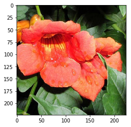

```python
imshow(process_image(image_path))
```

```
using cuda
type(probabilities): <class 'torch.Tensor'>
name = trumpet creeper
name = watercress
name = azalea
name = geranium
name = sword lily
```

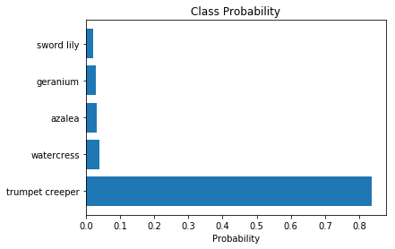

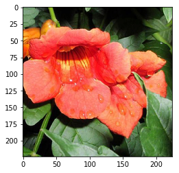

```python
# TODO: Display an image along with the top 5 classes
flower_probability, class_id_list = predict(image_path, model)
#print("type(class_ids) is {}".format(type(class_id_list)))

# get class names from class_ids
# cat_to_name type: <class 'collections.OrderedDict'>; class_id_list is a list of strings
class_names = list()
for class_id in class_id_list:
    name = cat_to_name.get(class_id)
    print("name = " + name)
    class_names.append(name)

# convert the data from FloatTensor to a plain old python list
probs = flower_probability.data.tolist()[0]
#print("type(ps): {}".format(type(probs)))
#print("ps items \n", probs)
# type(ps): <class 'list'>
# ps items
# [0.9999085068702698, 2.724911792029161e-05, 2.672913069545757e-05, 5.879443961021025e-06, 4.717463525594212e-06]



#imshow(process_image(image_path))
# https://www.youtube.com/watch?v=tfDZ4aN4giY
y_pos = np.arange(len(class_names))
plt.barh(y_pos, probs, align='center')
plt.title("Class Probability")
plt.yticks(y_pos, class_names)
plt.xlabel("Probability")
plt.show();

imshow(process_image(image_path));
```

# aimee's notes

Label mapping

You'll also need to load in a mapping from category label to category name. You can find this in the file cat_to_name.json. It's a JSON object which you can read in with the json module. This will give you a dictionary mapping the integer encoded categories to the actual names of the flowers.

What this does is converts the cat_to_name.json file to a dictionary named cat_to_name where: `key = a category` represented by a string of digits (that's a string not an integer) `value = category name` that's a string of characters.

This means that `print(cat_to_name['21']` prints fire lily and `print(cat_to_name['46']` prints wallflower

If your classes are integers you will need to convert (cast) them to strings to get the dictionary to provide the appropriate flower name. You can check the type of the variable returned by using the type() function. So

```
myInt = 21
print(type(myInt), cat_to_name[str(myInt)])
```

would print fire lily

```
with open('cat_to_name.json', 'r') as f:

    cat_to_name = json.load(f)

print("cat_to_name type: {}".format(type(cat_to_name)))

cat_to_name type: <class 'dict'>
```

# this plotting doesn't work

```
# TODO: Display an image along with the top 5 classes
flower_probability, class_id_list = predict(image_path, model)
print("type(class_ids) is {}".format(type(class_id_list)))

# get class names from class_ids
# cat_to_name type: <class 'collections.OrderedDict'>; class_id_list is a list of strings
class_names = list()
for class_id in class_id_list:
    name = cat_to_name.get(class_id)
    print("name = " + name)
    class_names.append(name)

# convert the data from FloatTensor to a plain old python list
probs = flower_probability.data.tolist()[0]
print("type(ps): {}".format(type(probs)))
print("ps items \n", probs)
# type(ps): <class 'list'>
# ps items
# [0.9999085068702698, 2.724911792029161e-05, 2.672913069545757e-05, 5.879443961021025e-06, 4.717463525594212e-06]

y_pos = np.arange(len(class_names))

fig, (ax1, ax2) = plt.subplots(figsize=(6,7), ncols=2)
img = process_image(image_path)
ax1 = imshow(ax1)
ax1.axis('off')
ax2.barh(y_pos, probs)
ax2.set_aspect(0.1)
#ax2.set_yticks(np.arange(10))
ax2.set_yticklabels(class_names, size='large');
ax2.set_title('Class Probability')
ax2.set_xlim(0, 1.1)
```

matplotlib.pyplot.barh

[dropout docs](https://pytorch.org/docs/master/nn.html#dropout)

During training, randomly zeroes some of the elements of the input tensor with probability p using samples from a Bernoulli distribution. The elements to zero are randomized on every forward call.

This has proven to be an effective technique for regularization and preventing the co-adaptation of neurons as described in the paper Improving neural networks by preventing co-adaptation of feature detectors .

# copied from helper.py, an instructor-written, hidden file that was part of Intro to Python module

```
def view_classify(img, ps):
    ''' Function for viewing an image and its predicted classes.
    '''
    ps = ps.data.numpy().squeeze()

    fig, (ax1, ax2) = plt.subplots(figsize=(6,7), ncols=2)
    ax1.imshow(img.numpy().squeeze())
    ax1.axis('off')
    ax2.barh(np.arange(10), ps)
    ax2.set_aspect(0.1)
    ax2.set_yticks(np.arange(10))
    ax2.set_yticklabels(np.arange(10).astype(int), size='large');
    ax2.set_title('Class Probability')
    ax2.set_xlim(0, 1.1)
```

print statements for debugging

```
print("raw image size {}".format(raw_image.size))
    print("raw image after thumbnail size width {} height {}".format(width, height))
    print("raw_image_crop size {}".format(raw_image_crop.size))

    print("type(np_raw_image[0][0][0]): {}".format(type(np_raw_image[0][0][0])))
    print("type(np_raw_image[1][1][1]): {}".format(type(np_raw_image[1][1][1])))
    print("type(np_raw_image[2][2][2]): {}".format(type(np_raw_image[2][2][2])))

    print("type(transposed_image[0][0][0]): {}".format(type(transposed_image[0][0][0])))
    print("type(transposed_image[1][1][1]): {}".format(type(transposed_image[1][1][1])))
    print("type(transposed_image[2][2][2]): {}".format(type(transposed_image[2][2][2])))

    print("type(tensor_image): {}".format(type(tensor_image))) # DoubleTensor
    print("type(tensor_image[0][0][0]): {}".format(type(tensor_image[0][0][0])))
    print("type(tensor_image[1][1][1]): {}".format(type(tensor_image[1][1][1])))
    print("type(tensor_image[2][2][2]): {}".format(type(tensor_image[2][2][2])))
    print("tensor_image size {}".format(tensor_image.size()))
```

[topk docs](https://pytorch.org/docs/master/torch.html#torch.topk)

Returns the k largest elements of the given input tensor along a given dimension.

If dim is not given, the last dimension of the input is chosen.

If largest is False then the k smallest elements are returned.

A tuple of (values, indices) is returned, where the indices are the indices of the elements in the original input tensor.

The boolean option sorted if True, will make sure that the returned k elements are themselves sorted

Parameters:

- input (Tensor) – the input tensor
- k (int) – the k in “top-k”
- dim (int, optional) – the dimension to sort along
- largest (bool, optional) – controls whether to return largest or smallest elements
- sorted (bool, optional) – controls whether to return the elements in sorted order
- out (tuple, optional) – the output tuple of (Tensor, LongTensor) that can be optionally given to be used as output buffers

Example:

```
>>> x = torch.arange(1., 6.)
>>> x
tensor([ 1.,  2.,  3.,  4.,  5.])
>>> torch.topk(x, 3)
(tensor([ 5.,  4.,  3.]), tensor([ 4,  3,  2]))
```

Giu [Yesterday at 10:06] in #cohort_april Passed the review and hopefully soon graduated after ID verification is completed! A very special thank you to @Abdel and @Mat for helping me through some parts that felt difficult (-: (edited)

5 replies Abdel A. [1 day ago] Good job!

Muhammad Rayyan Siddiqui [14 hours ago] How are you converting the indices in the topk variable to those of the class_to_idx?

Muhammad Rayyan Siddiqui [14 hours ago] I need som ehelp

Muhammad Rayyan Siddiqui [14 hours ago] *some help

Chan Jian Hui Jonathan [13 hours ago] In the Jupyter notebook there are instructions asking you to invert the class_to_idx dictionary first.

The reason being that topk returns a list of indices not classes. So you would need the dictionary of idx to class to convert all the indices to the respective classes. There after get the names of each class from the class_to_name dictionary that you already loaded at the start